# ADSP 31014 Statistical Models for Data Science

Copyright © 2026 Danny Ng

October 6, 2026

# 1 Prerequisite

Here is a review of some prerequisite topics for this course.

## 1.1 Expectation

- Expectation $\mathbb{E}$ is always linear i.e. if $X_1,\dotsc,X_n$ are any random variables and $a_1,\dotsc,a_n$ are any constants, then
  $$\mathbb{E}(a_1
  X_1+\dotsb+a_n X_n) = a_1\mathbb{E}(X_1) + \dotsb +
  a_n\mathbb{E}(X_n)$$
- Special case #1: For linear (or affine) transformation of one random variable $X$,
  $$\mathbb{E}(aX+b) = a\,\mathbb{E}(X) +
  b$$
- If $X\perp Y$ are independent, then
  $$\mathbb{E}(XY) =
  \mathbb{E}(X)\,\mathbb{E}(Y)$$

## 1.2 Variance, Standard Deviation

- By definition,
  $$\begin{align}
  \text{Var}(X) &= \mathbb{E}(X - \mathbb{E}(X))^2 = \mathbb{E}(X^2) -
  (\mathbb{E}(X))^2\geq 0\\
  \text{SD}(X) &= \sqrt{\text{Var}(X)}\geq 0
  \end{align}$$
- If $X\equiv c$ is a constant i.e. not random, then it does not vary i.e.
  $$\text{Var}(c) = 0 = \text{SD}(c)$$
- If $X_1,\dotsc,X_n$ are any random variables and $a_1,\dotsc,a_n$ are any constants, then
  $$\text{Var}(a_1
  X_1+\dotsb+a_n X_n) = a_1^2\text{Var}(X_1) + \dotsb +
  a_n^2\text{Var}(X_n) + 2 \sum_{1\leq i < j\leq n}a_i
  a_j\text{Cov}(X_i, X_j)$$
- Special case #1: If $X_1,\dotsc,X_n$ are independent, then all $\text{Cov}(X_i, X_j)=0$ so
  $$\text{Var}(a_1 X_1+\dotsb+a_n X_n) =
  a_1^2\text{Var}(X_1) + \dotsb + a_n^2\text{Var}(X_n)$$
- Special case #2: For two random variables $X$ and $Y$,
  $$\text{Var}(X + Y) = \text{Var}(X) + \text{Var}(Y)
  + 2\,\text{Cov}(X,Y)$$
  This means whether the “variance of the sum” is larger (or smaller) than the “sum of the variances” depends on if $X$ and $Y$ are positively (or negatively) correlated.
- Special case #3: If $Y\equiv b$ is a constant, then $\text{Var}(b) = 0$ and $\text{Cov}(X,b) = 0$ so
  $$\begin{align}
  \text{Var}(aX+b) &= a^2\text{Var}(X)\\
  \text{SD}(aX+b) &= |a|\,\text{SD}(X)
  \end{align}$$
  In other words, variance and standard deviation are not affected by translation by $b$. But variance is in “squared unit of measurement” so it is scaled by $a^2$ instead of just $|a|$.

```r
x <- rnorm(5)
var(x)
var(x + 10)
var(10 * x)
```

```
[1] 0.4091077
[1] 0.4091077
[1] 40.91077
```

- If a random variable $X$ has finite variance $\text{Var}(X)<\infty$, then it will also have finite expectation $\left|\mathbb{E}(X)\right| <\infty$. Conversely, if a random variable $X$ does not have finite expectation i.e. $\mathbb{E}(X)=\infty$ or $-\infty$, then it will also have infinite variance $\text{Var}(X)=\infty$.

## 1.3 Covariance, Correlation

- By definition,
  $$\text{Cov}(X,Y) =
  \mathbb{E}\left((X-\mathbb{E}(X))(Y-\mathbb{E}(Y))\right) =
  \mathbb{E}(XY)-\mathbb{E}(X)\mathbb{E}(Y)$$
  $$\text{Corr}(X,Y) =
  \frac{\text{Cov}(X,Y)}{\text{SD}(X)\,\text{SD}(Y)}\in[-1,1]$$
- Variance is always self-covariance i.e.
  $$\begin{align}
  \text{Cov}(X, X) &= \text{Var}(X)\\
  \text{Corr}(X,X) &= 1
  \end{align}$$
- If $\text{Corr}(X,Y) = 1$, then $X$ and $Y$ are perfectly positively correlated. This only occurs when they are linearly related i.e. there exists some $a>0$ and $b$ such that
  $$X = aY + b$$
  Similarly, if $\text{Corr}(X,Y) = -1$, then $a < 0$.
- If $X\perp Y$ are independent random variables, then
  $$\text{Cov}(X,Y) = \mathbb{E}(XY) - \mathbb{E}(X)\mathbb{E}(Y) = 0$$

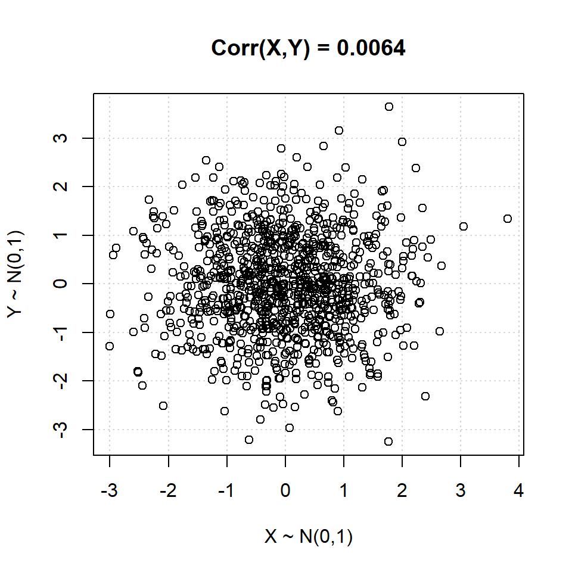

```r
n <- 1000
x <- rnorm(n)
y <- rnorm(n)

plot(x, y)
```

- But the converse is not true i.e. random variables can be uncorrelated but are still dependent. This is because covariance (and hence correlation) measures **linear association** only.

```r
n <- 100
x <- seq(-1, 1, length.out = n)
y <- x^2 + 0.05 * rnorm(n)
y <- y - sum(x * y) / sum(x * x) * x # Residual of orthogonal projection

cor(x, y)
```

```
[1] -1.451212e-16
```

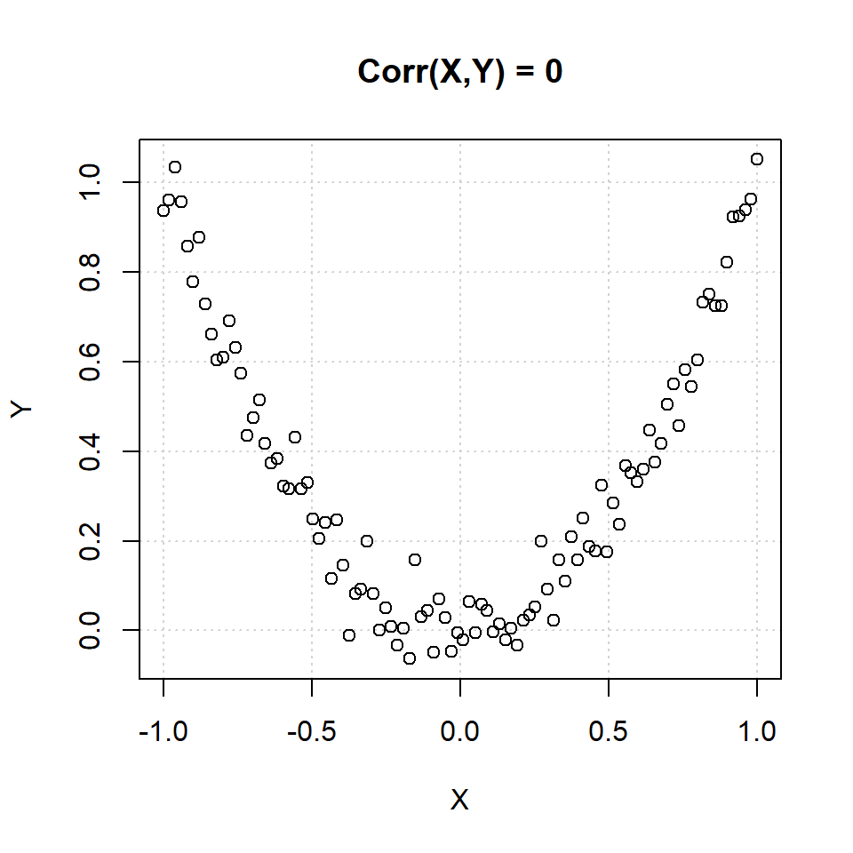

- If $Y\equiv c$ is a constant i.e. not random, then it is always independent of (and hence uncorrelated with) any other random variable $X$.
  $$\text{Cov}(X,c) = 0 =
  \text{Corr}(X,c)$$
- If $X_1,\dotsc,X_n,Y_1,\dotsc,Y_m$ are any random variables and $a_1,\dotsc,a_n,b_1,\dotsc,b_m$ are any constants, then
  $$\text{Cov}(a_1
  X_1+\dotsb+a_n X_n,\,b_1 Y_1+\dotsb+b_m Y_m) = \sum_{i=1}^n\sum_{j=1}^m
  a_i b_j \text{Cov}(X_i,Y_j)$$
- Special case #1: Since variance is self-covariance, all cases for variance above is a special case of this.
- Special case #2: For 4 random variables,
  $$\text{Cov}(X+Y,U+V) =
  \text{Cov}(X,U)+\text{Cov}(X,V)+\text{Cov}(Y,U)+\text{Cov}(Y,V)$$
- Special case #3: For positive linear (or affine) transformation with $a > 0$ and $c > 0$,
  $$\text{Corr}(aX+b, cY+d) =
  \text{Corr}(X,Y)$$
  In other words, correlation is not affected by translation or positive scaling.

```r
x <- rnorm(10)
y <- rnorm(10)
cor(x, y)
cor(2 * x + 3, 4 * y + 5)
```

```
[1] -0.3487052
[1] -0.3487052
```

```r
n <- 100
x <- runif(n, -1, 1)
y <- x + 0.5 * rnorm(n)

y1 <- y
y2 <- 2 * y
y3 <- 5 * y
```

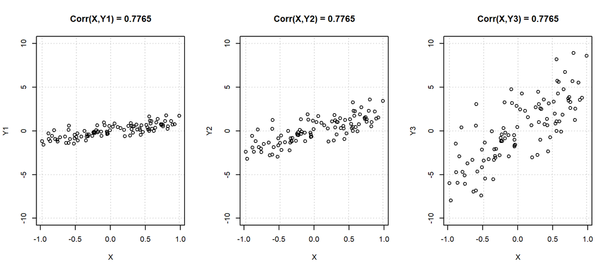

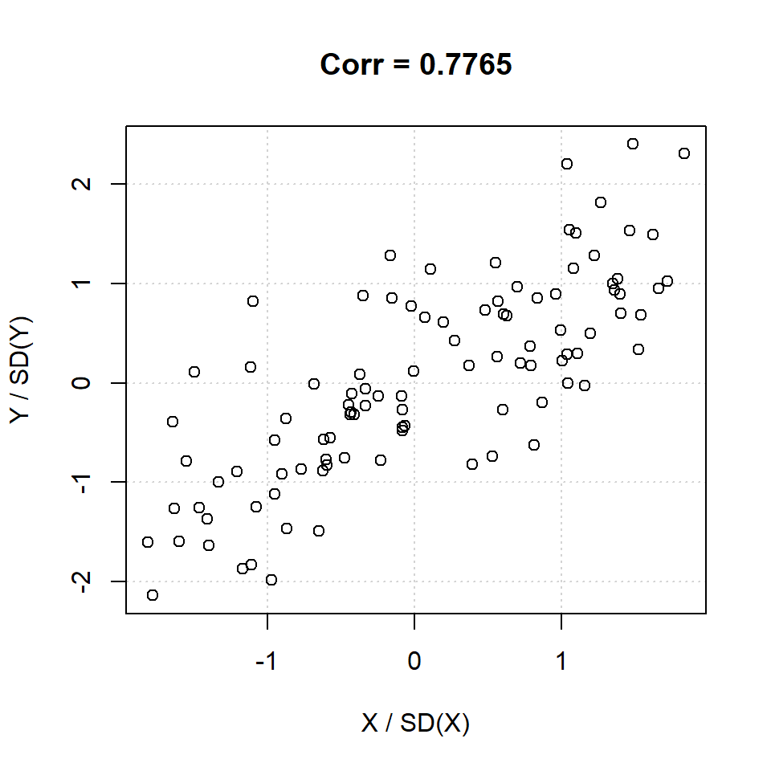

```r
plot(x / sd(x), y / sd(y))
```

```r
n <- 100
x <- runif(n, -1, 1)
noise <- rnorm(n)
y1 <- x + 5 * noise
y2 <- x + 0.8 * noise
y3 <- x + 0.3 * noise
```

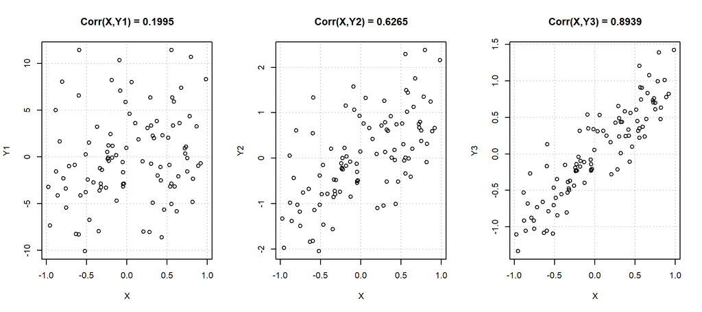

- In practice, $\text{Corr}(X,Y)\approx 0.6$ is a reasonably high correlation value.

# 2 Modeling

- We usually start with a set of $n$ observed **data points** $x_1,\dotsc,x_n$ or $n$ pairs of data $(x_1,y_1),\dotsc,(x_n,y_n)$. Sometimes each data point $x_i$ is not just a number but a $d$-dimensional vector $\vec{x}_i=(x_{i1},\dotsc,x_{id})\in\mathbb{R}^d$ with $d$ pieces of information.
- *Example:* $\vec{x}=\,$(age, sex, race, height, weight, blood pressure) and $y=\,$ cholesterol level
- A **model** is a simplified assumption about the underlying structure of the observed data.
- **Modeling** is the task of developing a suitable model that describes the observed data adequately. With this, we can:
  - Understand relationships within the data e.g. independence, low-dimensional
  - Perform clustering, dimension reduction, missing data imputation
  - Identify unusual observation / outlier / anomaly detection
  - Determine if a new observation is plausibly of the same kind
  - Predict / forecast the value of $y$ for some unseen value of $x$

## 2.1 Parametric vs Non-Parametric

- A **parametric model** is one in which the model can be parameterized (or completely described) by a fixed number of parameters $\theta$ irrespective of the number $n$ of observed data.
- *Example:* Let $x_1,\dotsc,x_n\in\{0,1\}$ be a sequence of observed coin tosses from a possibly unfair coin. We can model using a Bernoulli distribution $\text{Bern}(p)$ with parameter $\theta=p$ regardless of the number $n$ of tosses.
- *Example:* Let $x_1,\dotsc,x_n\in\mathbb{R}$ be the observed cholesterol level values of $n$ patients at a hospital. We can model using a normal distribution $\mathcal{N}(\mu,\sigma^2)$ with $2$-dimensional parameter $\theta=(\mu,\sigma^2)$.
- *Example:* Linear regression model assumes a linear relationship $y \approx \beta_0 + \beta_1 x_1 + \dotsb + \beta_d x_d$ between output $y$ and a number of inputs $x_1,\dotsc,x_d$ weighed by a fixed $d+1$ number of parameters $\beta_0,\dotsc,\beta_d$.
- A **non-parametric model** is one in which the number of parameters of the model increases with the number of observed data.
- *Example:* In machine learning, $k$-[nearest neighbors](https://en.wikipedia.org/wiki/K-nearest_neighbors_algorithm) $k$-NN algorithm whose model complexity is proportional to the number of observed data points, or [local regression](https://en.wikipedia.org/wiki/Local_regression) e.g. LOESS in which a separate regression model is fitted around each data point.
- In this course, we focus on parametric model.

# 3 Linear Regression Part 1

- Let $(\vec{x}_1,y_1),\dotsc,(\vec{x}_n,y_n)$ be $n$ pairs of observed data points. In general, the objective of **supervised** machine learning modeling is to learn a mathematical relationship $f$ between $\vec{x}$’s and **target label** $y$’s i.e.
  $$y = f(\vec{x}) + \epsilon$$
  In statistics, computer science, and machine learning literature and terminology:
  - $\vec{x}$ is the **explanatory** variable / **independent** variable / predictor / **covariate** / **input feature**. In general, $\vec{x}=(x_1,\dotsc,x_d)\in\mathbb{R}^d$ is a $d$-dimensional vector which represents $d$ pieces of information.
  - $y$ is the **response** variable / **dependent** variable / prediction / outcome / output.
  - $f$ is the model. In practice, it can be any mathematical function e.g. linear formula, decision tree, neural net, etc.
  - $\epsilon$ is the **error** / **residual** / **noise** that cannot be explained by the model $f$.
- If $y\in\mathbb{R}$ is numerical / quantitative / continuous, then it is a **regression** task. On the other hand, if $y\in\{c_1,\dotsc,c_k\}$ is a categorical / qualitative variable, then it is a **classification** task.

## 3.1 Linear Model

- For linear regression, the model $f$ represents a linear relationship between $\vec{x}$ and $y$ as follows:
  $$y = \underbrace{\beta_0 + \beta_1 x_1 + \dotsb +
  \beta_d x_d}_{f(\vec{x})} + \epsilon$$
  Here $\beta_0,\dotsc,\beta_d$ are the **coefficients** / parameters / **weights** of the model. They are unknown and to be estimated using the observed data.
- The model equation $f$ is “linear” because it involves a **linear combination** (in the sense of linear algebra) of the $d$ explanatory variables $x_1,\dotsc,x_d$.
- Interpretation of coefficient $\beta_j$: If $x_j$ increases by $+1$ unit to become $x_j + 1$, then $y$ should increase by $+\beta_j$ units.
- If $d = 1$ i.e. only one explanatory variable, then it is **simple linear regression**. Otherwise, if $d \geq 2$, then it is **multiple linear regression**.
- *Example:* The following model equation is still linear if we consider it as a relationship between $y$ and some new input features $x_3 = \log{x_1}$, $x_4 = (x_2)^2$, and $x_5 = x_1 x_2$.
  $$y = \beta_1 \underbrace{\log{x_1}}_{x_3} +
  \beta_2 \underbrace{(x_2)^2}_{x_4} + \beta_3 \underbrace{x_1 x_2}_{x_5}
  + \epsilon$$
- *Example:* The following model equation between $y$ and $x$ cannot be rewritten in the linear form so it is not a linear model.
  $$y = \beta_0 +
  \beta_1 x^{\beta_2} + \epsilon$$

## 3.2 Simple Linear Regression, Ordinary Least Squares

- How do we find the optimal $\beta_0^*,\dotsc,\beta_d^*$ parameters? Let’s start with simple linear regression.

```r
x <- c(0.4, 0.8, 1.2, 1.7, 2.1)
y <- c(2, 5, 4.3, 4.2, 8)
```

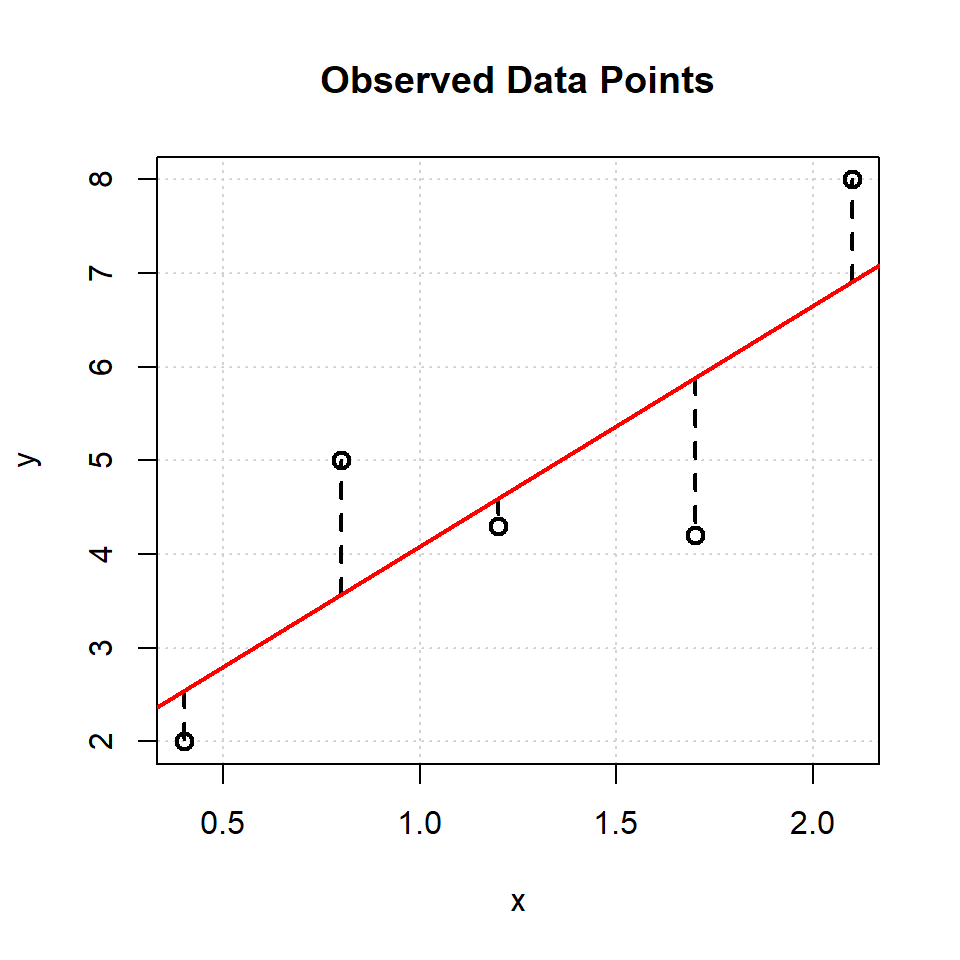

- Model equation is
  $$y =
  \underbrace{\beta_0 + \beta_1 x}_\text{line}+\epsilon$$
  with unknown intercept $\beta_0$ and slope $\beta_1$ parameters for the line.
- Let’s measure the **goodness-of-fit** of any particular line $y = \beta_0+ \beta_1 x$ based on the **mean squared error MSE** metric
  $$\text{MSE} = \frac{1}{n}\sum_{i=1}^n
  \big(\underbrace{y_i - (\overbrace{\beta_0 + \beta_1
  x_i}^{\text{predicted } \hat{y}_i})}_{\text{residual }r_i\text{ or error
  }e_i}\big)^2$$
  on the observed data. Here:
  - $\beta_0 + \beta_1 x_i$ is the **fitted** / **predicted value** (denoted by $\hat{y}_i$) along the line for the $i^\text{th}$ data point $x_i$.
  - $y_i - \hat{y}_i$ is the **residual** (denoted by $r_i$) or **error** (denoted by $e_i$) of the prediction. In the plot above, it corresponds to the vertical discrepancy between the observed **true value** / **ground truth** $y_i$ and the line.
  - MSE is the total discrepancy over the entire observed data set.
- Why do we use MSE? As an example, isn’t it simpler and more intuitive to use **mean absolute error MAE**
  $$\text{MAE} = \frac{1}{n}\sum_{i=1}^n \big|y_i -
  (\beta_0 + \beta_1 x_i)\big|$$
  instead? The main reason is that a quadratic function $f(x)=x^2$ is differentiable but an absolute value function $f(x)=|x|$ is not.
- If a residual $r_i$ has large (positive or negative) value, then its squared value $r_i^2$ is even larger. Therefore, MSE is easily impacted by an outlier. As a result, linear regression is not very robust against outliers.
- To find the optimal line and its intercept $\beta_0^*$ and slope $\beta_1^*$, the **ordinary least squares OLS** method seeks to minimize the MSE **loss** / **cost** / **objective function**
  $$\min_{\beta_0,\beta_1}\,\underbrace{\frac{1}{n}\sum_{i=1}^n
  \big(y_i - (\beta_0 + \beta_1 x_i)\big)^2}_\text{MSE}$$
  (In modern machine learning paradigm, this is a common approach to **learn** a model by optimizing a metric over a **training data** set.)
- By using calculus to differentiate the MSE with respect to its variables $\beta_0$ and $\beta_0$ and applying the [first-order condition](https://en.wikipedia.org/wiki/Derivative_test#First-derivative_test), we obtain the optimal slope parameter
  $$\beta_1^* = \frac{\sum_{i=1}^n
  (x_i-\bar{x}_n)(y_i-\bar{y}_n)}{\sum_{i=1}^n (x_i-\bar{x}_n)^2} =
  \frac{\text{Cov}(X,Y)}{\text{Var}(X)} =
  \text{Corr}(X,Y)\frac{\text{SD}(Y)}{\text{SD}(X)}$$
  and intercept parameter
  $$\beta_0^* = \bar{y}_n - \beta_1^*
  \bar{x}_n$$
  Note those are sample $\text{Cov}(\dotso)$, $\text{Var}(\dotso)$, and $\text{SD}(\dotso)$.
- In R, use built-in `lm()` function to fit linear regression model.

```r
model <- lm(y ~ x) # See ?formula for syntax

# Beta's
model
model$coefficients # See str(model)
coef(model)
coefficients(model)
summary(model)
```

```
Call:
lm(formula = y ~ x)

Coefficients:
(Intercept)            x
      1.513        2.570
```

```
(Intercept)           x
   1.512959    2.570194
```

```
(Intercept)           x
   1.512959    2.570194
```

```
(Intercept)           x
   1.512959    2.570194
```

```
Call:
lm(formula = y ~ x)

Residuals:
      1       2       3       4       5
-0.5410  1.4309 -0.2972 -1.6823  1.0896

Coefficients:
            Estimate Std. Error t value Pr(>|t|)
(Intercept)    1.513      1.488   1.017   0.3841
x              2.570      1.077   2.386   0.0971 .
---
Signif. codes:  0 '***' 0.001 '**' 0.01 '*' 0.05 '.' 0.1 ' ' 1

Residual standard error: 1.466 on 3 degrees of freedom
Multiple R-squared:  0.6549,    Adjusted R-squared:  0.5399
F-statistic: 5.694 on 1 and 3 DF,  p-value: 0.09707
```

```r
# Compute b0 and b1 manually
(b1 <- cov(x,y) / var(x)) # Same as cor(x, y) * sd(y) / sd(x)

x.bar <- mean(x)
y.bar <- mean(y)
(b0 <- y.bar - b1 * x.bar)
```

```
[1] 2.570194
[1] 1.512959
```

```r
# Fitted values / predictions
fitted(model)
fitted.values(model)
model$fitted.values
```

```
       1        2        3        4        5
2.541037 3.569114 4.597192 5.882289 6.910367
       1        2        3        4        5
2.541037 3.569114 4.597192 5.882289 6.910367
       1        2        3        4        5
2.541037 3.569114 4.597192 5.882289 6.910367
```

```r
# Residuals / errors
residuals(model) # Same as resid(model)
model$residuals
y - fitted(model)
```

```
         1          2          3          4          5
-0.5410367  1.4308855 -0.2971922 -1.6822894  1.0896328
         1          2          3          4          5
-0.5410367  1.4308855 -0.2971922 -1.6822894  1.0896328
         1          2          3          4          5
-0.5410367  1.4308855 -0.2971922 -1.6822894  1.0896328
```

```r
# Mean squared error MSE
mean(residuals(model) ^ 2)
deviance(model) / length(y)
```

```
[1] 1.289175
[1] 1.289175
```

- Linear regression model is effectively invariant to **affine transformation** $x\mapsto c_1 + c_2 x$ of an explanatory variable. In this case, the model prediction $\hat{y}$ does not change.
  - **Scaling:** If we scale an explanatory variable $x$ to become $c\,x$, then $\beta_1^*$ is scaled accordingly to become $(1/c)\,\beta_1^*$. But $\beta_0^*$ does not change.
  - **Translation:** If we translate an explanatory variable $x$ to become $x+c$, then $\beta_1^*$ does not change. Now $\beta_0^*$ becomes $\beta_0^* - \beta_1^*c$ to compensate.

```r
lm(y ~ x)

x10 <- x * 10
lm(y ~ x10) # b1 becomes 0.1 * b1

x2 <- x + 2
lm(y ~ x2) # b0 becomes b0 - 2 * b1
```

```
Call:
lm(formula = y ~ x)

Coefficients:
(Intercept)            x
      1.513        2.570
```

```
Call:
lm(formula = y ~ x10)

Coefficients:
(Intercept)          x10
      1.513        0.257
```

```
Call:
lm(formula = y ~ x2)

Coefficients:
(Intercept)           x2
     -3.627        2.570
```

- Based on the formulae for the optimal $\beta_0^*$ and $\beta_1^*$ parameters:
  - Re-arranging $\beta_0^*$ as
    $$\bar{y}_n = \beta_0^* + \beta_1^*
    \bar{x}_n$$
    shows that the optimal line $y = \beta_0^* + \beta_1^* x$ passes through the point $(\bar{x}_n, \bar{y}_n)$ which is the center of mass of all data points.
  - If we standardize each of the $x$’s and $y$’s to have mean $\bar{x}_n =\bar{y}_n=0$ and standard deviation $\text{SD}(X) = \text{SD}(Y) = 1$, then
    $$\beta_1^* =
    \text{Corr}(X,Y)\frac{\text{SD}(Y)}{\text{SD}(X)} =
    \text{Corr}(X,Y)\quad\text{and}\quad \beta_0^* = \bar{y}_n - \beta_1^*
    \bar{x}_n = 0$$
    This means the kind of linear relationship between $x$ and $y$ that is learned by the linear regression model (represented by $\beta_1^*$) is same as the kind of linear association described by their correlation $\text{Corr}(X,Y)$.

```r
x.std <- scale(x) # Standardize x
y.std <- scale(y)

lm(y.std ~ x.std) # Intercept b0 = 0 and slope b1 = cor(x, y)
cor(x, y)
```

```
Call:
lm(formula = y.std ~ x.std)

Coefficients:
(Intercept)        x.std
     0.0000       0.8093

[1] 0.8092785
```

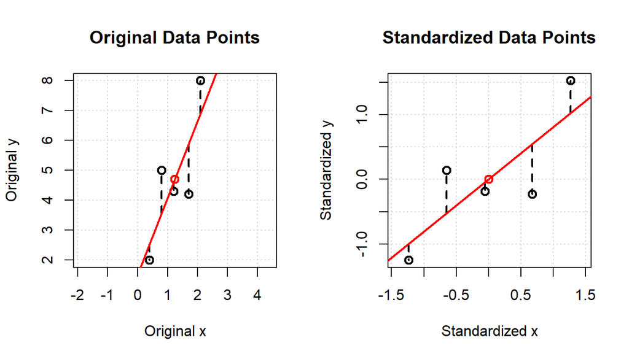

- In R, use `predict(..., newdata = ...)` function to predict on new explanatory data stored in a `data.frame()`.

```r
# Use predict()
model <- lm(y ~ x)
predict(model, newdata = data.frame(x=10))
```

```
      1
27.2149
```

```r
# Compute prediction manually
b0 <- coef(model)[1]
b1 <- coef(model)[2]
b0 + b1 * 10
```

```
(Intercept)
    27.2149
```

- In R, it is best practice to store the training data in a `data.frame()` and use the `lm(..., data = ...)` syntax. In this way, the fitted model remembers the naming and format of the explanatory variables from the data so `predict(..., newdata = ...)` knows how to extract the explanatory variables from new data of the same kind.

```r
data <- data.frame(x = c(0.4, 0.8, 1.2, 1.7, 2.1),
                   y = c(2, 5, 4.3, 4.2, 8))

model <- lm(y ~ x, data = data)
predict(model, newdata = data.frame(x = 10)) # Same format as training data
```

```
      1
27.2149
```

- If a model is not aware of the specific data format, then R cannot understand the structure of the new data. It would simply return the fitted values as predictions.

```r
model <- lm(data$y ~ data$x)
predict(model, newdata=data.frame(x = 10)) # Original fitted values
```

```
       1        2        3        4        5
2.541037 3.569114 4.597192 5.882289 6.910367
```

## 3.3 Multiple Linear Regression

- See `adsp31014_mlr.pdf`.

```r
x <- c(0.4, 0.8, 1.2, 1.7, 2.1)
y <- c(2, 5, 4.3, 4.2, 8)
model <- lm(y ~ x)

(X <- model.matrix(y ~ x)) # Design matrix with first column of 1's for intercept
```

```
  (Intercept)   x
1           1 0.4
2           1 0.8
3           1 1.2
4           1 1.7
5           1 2.1
attr(,"assign")
[1] 0 1
```

```r
(beta <- solve(t(X) %*% X, t(X) %*% y))
coef(model)
```

```
                [,1]
(Intercept) 1.512959
x           2.570194
(Intercept)           x
   1.512959    2.570194
```

```r
X %*% beta
fitted(model)
```

```
      [,1]
1 2.541037
2 3.569114
3 4.597192
4 5.882289
5 6.910367
       1        2        3        4        5
2.541037 3.569114 4.597192 5.882289 6.910367
```

## 3.4 Coefficient of Determination ${\small R^2}$

- The simplest linear regression model is the **null model** with only the intercept parameter $\beta_0$ and no explanatory variable i.e.
  $$y = \beta_0 + \epsilon$$
  In this case, the optimal intercept parameter $\beta_0^* = \bar{y}_n$ is simply the sample mean of the response values. As a result, the fitted / predicted value $\hat{y}_i = \beta_0^* = \bar{y}_n$ is a constant. The total error of this constant model on the observed data is
  $$SS_\text{total} =
  \sum_{i=1}^n (y_i - \bar{y}_n)^2$$
  This is called the **total sum of squares**. It represents the total amount of variation within the response values $y_1,\dotsc,y_n$.
- When we use a more sophisticated linear regression model with one or more explanatory variables i.e.
  $$y = \beta_0
  + \beta_1 x_1 + \dotsb + \beta_d x_d + \epsilon$$
  it can fit the observed data better i.e. $y_i \approx \hat{y}_i$ so the amount of error of this model
  $$SS_\text{error} = \sum_{i=1}^n (y_i -
  \hat{y}_i)^2 < SS_\text{total}$$
  is smaller than $SS_\text{total}$. This is called the **residual** / **error sum of squares** (sometimes denoted by $SS_\text{res}$). It represents the amount of variation in the response values that is unexplained by the explanatory variables.
- At the same time, each fitted value $\hat{y}_i$ is likely farther away from the overall mean $\bar{y}_n$. So the quantity
  $$SS_\text{reg} = \sum_{i=1}^n
  (\hat{y}_i - \bar{y}_n)^2 > 0$$
  increases. This is called the **model** / **regression sum of squares** (sometimes denoted by $SS_\text{model}$).
- Fact: We have the exact decomposition
  $$\underbrace{\sum_{i=1}^n (y_i -
  \bar{y}_n)^2}_{SS_\text{total}} = \underbrace{\sum_{i=1}^n (\hat{y}_i -
  \bar{y}_n)^2}_{SS_\text{reg}} + \underbrace{\sum_{i=1}^n (y_i -
  \hat{y}_i)^2}_{SS_\text{error}}$$
  (This is only true when the linear regression model has an intercept parameter.)
- This motivates us to measure the goodness-of-fit of a linear regression model based on the **coefficient of determination**
  $$R^2 =
  \frac{SS_\text{reg}}{SS_\text{total}} = 1 -
  \frac{SS_\text{error}}{SS_\text{total}}\in[0,1]$$
  (The definition of $R^2$ is slightly different for linear regression model without the intercept term. See R’s `?summary.lm` documentation. These two definitions are not comparable.) It represents the percentage / proportion of variation in the response variable that can be explained by the explanatory variables of the model.

```r
x <- c(0.4, 0.8, 1.2, 1.7, 2.1)
y <- c(2, 5, 4.3, 4.2, 8)
model <- lm(y ~ x)

# Compute various sums of squares
ss.total <- sum((y - mean(y)) ^ 2)
ss.reg <- sum((fitted(model) - mean(y)) ^ 2)
ss.error <- sum((y - fitted(model)) ^ 2) # Same as deviance(model)

c(ss.total, ss.reg, ss.error) # SST = SSR + SSE
```

```
[1] 18.680000 12.234125  6.445875
```

```r
# Coefficient of determination R^2
cor(y, fitted(model)) ^ 2
ss.reg / ss.total # SSR / SST
1 - ss.error / ss.total # 1 - SSE / SST
summary(model)$r.squared
```

```
[1] 0.6549318
[1] 0.6549318
[1] 0.6549318
[1] 0.6549318
```

- Note $0 < R^2 < 1$ is “normalized” in the sense that $SS_\text{reg}$ and $SS_\text{error}$ are benchmarked against $SS_\text{total}$ of the baseline constant model with only the intercept.
- If $R^2 \approx 1$, then $SS_\text{reg}\approx SS_\text{total}$ and $SS_\text{error}\approx 0$ so the model explains the response variable well. If $R^2 = 1$, then $SS_\text{error}= 0$ so all predictions are perfect i.e. $y_i = \hat{y}_i$ with no error or residual.
- If $R^2 = 0$, then the linear regression model does as poorly as the constant model with only the intercept.
- How is $R^2$ related to MSE? Since $\text{MSE} = SS_\text{error} / n$ and $SS_\text{total}=c$ is a constant that does not depend on any particular linear regression model, we have
  $$R^2 = 1 -
  \frac{SS_\text{error}}{SS_\text{total}} = 1 - \frac{\text{MSE}\times
  n}{c}$$
  So $R^2$ and MSE are equivalent metrics that are related monotonically i.e. if one increases, then the other one decreases.
- Fact: For linear regression model with intercept, we have
  $$R^2 = \text{Corr}(Y, \hat{Y})^2$$
  Note this is sample $\text{Corr}(...)$.

## 3.5 Multicollinearity

- In multiple linear regression, with many explanatory variables $\vec{x} = (x_1,\dotsc,x_d)$ in the model to explain the response variable $y$, there is a higher chance that some of these $d$ explanatory variable are correlated. In this case, $\vec{x}\in\mathbb{R}^d$ might not represent $d$ separate pieces of information i.e. there is some redundancy. This is called **multicollinearity**. (Note this concept is focused on the explanatory variables $x_1,\dotsc,x_d$ themselves and has nothing to do with the response variable $y$.)
- If two explanatory variables $x_1$ and $x_2$ are perfectly correlated i.e. $\text{Corr}(x_1, x_2) = 1$, then their roles are exchangeable. For example, if $x_1 = x$ and $x_2 = 4\,x$, then the model equation
  $$y = 4 \,x_1 + 0\,x_2 =
  0\, x_1 + 1\, x_2 = 2\, x_1 + 0.5\,x_2$$
  can be represented in (infinitely) many ways. The model is **non-identifiable** because of the non-uniqueness of the model parameters. (This is exactly the same as the concept of linear dependence of vectors in linear algebra.)

```r
x1 <- c(0.4, 0.8, 1.2, 1.7, 2.1)
y <- c(2, 5, 4.3, 4.2, 8)

x2 <- 2 * x1 # Corr(x1, x2) = 1
summary(lm(y ~ x1 + x2)) # Same as y ~ x1 + I(x1 * 2)   See ?formula
```

```
Call:
lm(formula = y ~ x1 + x2)

Residuals:
      1       2       3       4       5
-0.5410  1.4309 -0.2972 -1.6823  1.0896

Coefficients: (1 not defined because of singularities)
            Estimate Std. Error t value Pr(>|t|)
(Intercept)    1.513      1.488   1.017   0.3841
x1             2.570      1.077   2.386   0.0971 .
x2                NA         NA      NA       NA
---
Signif. codes:  0 '***' 0.001 '**' 0.01 '*' 0.05 '.' 0.1 ' ' 1

Residual standard error: 1.466 on 3 degrees of freedom
Multiple R-squared:  0.6549,    Adjusted R-squared:  0.5399
F-statistic: 5.694 on 1 and 3 DF,  p-value: 0.09707
```

- Multicollinearity makes numerical computation unstable. Parameter estimation becomes very sensitive i.e. a small change in an explanatory variable $x_i$ might result in a large change in the values of (more than one) model parameters. Consequently, the model has poor **explainability** because a $+1$ unit increase in an explanatory variable $x_i$ does not imply a $+\beta_i$ unit increase in the response variable $y$ anymore. (Part of the reason is because a change in $x_i$ will also imply a change in other highly correlated explanatory variables so the scenario of “$+1$ unit in $x_i$ while having all else being the same” does not hold.)

```r
set.seed(1)

x1 <- c(0.4, 0.8, 1.2, 1.7, 2.1)
y <- c(2, 5, 4.3, 4.2, 8)

x2 <- x1 + rnorm(length(x1), mean = 0, sd=1e-4) # Add small noise
x2
```

```
[1] 0.3999374 0.8000184 1.1999164 1.7001595 2.1000330
```

```r
1 - cor(x1, x2) # Corr(x1, x2) is almost 1
```

```
[1] 6.710243e-09
```

```r
summary(lm(y ~ x1 + x2)) # Large magnitude of parameters
```

```
Call:
lm(formula = y ~ x1 + x2)

Residuals:
      1       2       3       4       5
-0.5868  1.6740 -0.8504 -1.0331  0.7963

Coefficients:
              Estimate Std. Error t value Pr(>|t|)
(Intercept)     0.9954     1.9294   0.516    0.657
x1           5935.0921 10586.4781   0.561    0.631
x2          -5932.0427 10585.6229  -0.560    0.632

Residual standard error: 1.669 on 2 degrees of freedom
Multiple R-squared:  0.7018,    Adjusted R-squared:  0.4035
F-statistic: 2.353 on 2 and 2 DF,  p-value: 0.2982
```

```r
x3 <- x2
x3[2] <- x3[2] + 1e-5 # Small change in explanatory variable
x3
```

```
[1] 0.3999374 0.8000284 1.1999164 1.7001595 2.1000330
```

```r
summary(lm(y ~ x1 + x3)) # Parameters become sensitive
```

```
Call:
lm(formula = y ~ x1 + x3)

Residuals:
      1       2       3       4       5
-0.6016  1.6788 -0.7903 -1.1210  0.8341

Coefficients:
             Estimate Std. Error t value Pr(>|t|)
(Intercept)     1.087      1.929   0.564    0.630
x1           5174.437  10574.416   0.489    0.673
x3          -5171.461  10573.587  -0.489    0.673

Residual standard error: 1.697 on 2 degrees of freedom
Multiple R-squared:  0.6918,    Adjusted R-squared:  0.3836
F-statistic: 2.245 on 2 and 2 DF,  p-value: 0.3082
```

- In general, multicollinearity can occur when one explanatory variable is correlated with a mix of a few other explanatory variables i.e. not just between a pair of two explanatory variables.

```r
set.seed(1)

n <- 5
m <- matrix(rnorm(n * 2), nrow = n, ncol = 2) %*% matrix(c(2, 0, -2, 3), nrow = 2, ncol = 2)
x1 <- m[,1]
x2 <- m[,2]

x1
x2
cor(x1, x2) # Not very correlated
```

```
[1] -1.2529076  0.3672866 -1.6712572  3.1905616  0.6590155
[1] -1.208498  1.095001  3.886231 -1.463218 -1.575181
[1] -0.5773345
```

```r
# Construct y
y <- 1 + 2 * x1 + 3 * x2 + rnorm(n, mean = 0, sd = 0.1)

lm(y ~ x1 + x2)
```

```
Call:
lm(formula = y ~ x1 + x2)

Coefficients:
(Intercept)           x1           x2
      1.033        1.917        2.950
```

```r
set.seed(2)

x3 <- x1 + 0.8 * x2 + rnorm(n, mean = 0, sd =1e-3)

x3
cor(x1, x3) # Not very correlated
cor(x2, x3)
cor(x3, x1 + 0.8 * x2) # Multicollinear
```

```
[1] -2.2206026  1.2434719  1.4393157  2.0188572 -0.6012093
[1] 0.4745505
[1] 0.4447389
[1] 0.9999998
```

```r
summary(lm(y ~ x1 + x2 + x3))
```

```
Call:
lm(formula = y ~ x1 + x2 + x3)

Residuals:
         1          2          3          4          5
-0.0116829  0.1002917 -0.0474113 -0.0409079 -0.0002896

Coefficients:
             Estimate Std. Error t value Pr(>|t|)
(Intercept)   1.04151    0.05671  18.367   0.0346 *
x1          -81.61755  141.49937  -0.577   0.6669
x2          -63.91393  113.26165  -0.564   0.6729
x3           83.53995  141.50896   0.590   0.6605
---
Signif. codes:  0 '***' 0.001 '**' 0.01 '*' 0.05 '.' 0.1 ' ' 1

Residual standard error: 0.1188 on 1 degrees of freedom
Multiple R-squared:  0.9999,    Adjusted R-squared:  0.9996
F-statistic:  3063 on 3 and 1 DF,  p-value: 0.01328
```

- How to detect general multicollinearity?
  1. For each explanatory variable $x_i$, we fit a multiple regression model with $x_i$ as the response variable to see how much it can be explained by the other explanatory variables $x_1,\dotsc,x_{i-1},x_{i+1},\dotsc,x_d$.
  2. If the linear regression model $R^2$ is high, then the model has found a linear combination of the other explanatory variables that together is highly (in fact, highest) correlated with $x_i$.
  3. Compute the **variance inflation factor VIF**
     $$\text{VIF} =
     \frac{1}{1-R^2}\in[1,\infty)$$
  4. In practice, if $\text{VIF}>5$ i.e. $R^2 > 0.8$ or correlation $|R| > 0.89$, then there is strong evidence of multicollinearity. In this case, we should consider omitting the explanatory variable $x_i$ from the modeling.

```r
(r2 <- summary(lm(x3 ~ x1 + x2))$r.squared)
(vif <- 1 / (1 - r2))
```

```
[1] 0.9999999
[1] 17419081
```

- Note the VIF procedure tells us if one explanatory variable is redundant when all the other explanatory variables already exist in the model. If two explanatory variables are highly correlated with each other, then they would both have high VIF values. But it doesn’t mean you should simply omit both variables from modeling. Perhaps you need to keep one of them.
- Although multicollinearity often affects the estimation of model parameters (and hence model explainability and identifiability), it usually DOES NOT affect the goodness-of-fit of the model (as measured by MSE or $R^2$) or prediction.

```r
set.seed(1)

n <- 100
x1 <- rnorm(n)
y <- 1 + 2 * x1 + rnorm(n)

m1 <- lm(y ~ x1)
summary(m1)
```

```
Call:
lm(formula = y ~ x1)

Residuals:
    Min      1Q  Median      3Q     Max
-1.8768 -0.6138 -0.1395  0.5394  2.3462

Coefficients:
            Estimate Std. Error t value Pr(>|t|)
(Intercept)  0.96231    0.09699   9.922   <2e-16 ***
x1           1.99894    0.10773  18.556   <2e-16 ***
---
Signif. codes:  0 '***' 0.001 '**' 0.01 '*' 0.05 '.' 0.1 ' ' 1

Residual standard error: 0.9628 on 98 degrees of freedom
Multiple R-squared:  0.7784,    Adjusted R-squared:  0.7762
F-statistic: 344.3 on 1 and 98 DF,  p-value: < 2.2e-16
```

```r
predict(m1, newdata = data.frame(x1 = 10))
```

```
      1
20.9517
```

```r
set.seed(2)

x2 <- 2 * x1 + rnorm(n, mean = 0, sd=1e-4)

m2 <- lm(y ~ x1 + x2)
summary(m2)
```

```
Call:
lm(formula = y ~ x1 + x2)

Residuals:
    Min      1Q  Median      3Q     Max
-1.8836 -0.6172 -0.1165  0.5317  2.3326

Coefficients:
              Estimate Std. Error t value Pr(>|t|)
(Intercept)    0.96216    0.09747   9.871 2.54e-16 ***
x1           334.18210 1696.40039   0.197    0.844
x2          -166.09323  848.20862  -0.196    0.845
---
Signif. codes:  0 '***' 0.001 '**' 0.01 '*' 0.05 '.' 0.1 ' ' 1

Residual standard error: 0.9675 on 97 degrees of freedom
Multiple R-squared:  0.7785,    Adjusted R-squared:  0.774
F-statistic: 170.5 on 2 and 97 DF,  p-value: < 2.2e-16
```

```r
predict(m2, newdata = data.frame(x1 = 10, x2 = 20))
```

```
       1
20.91857
```

## 3.6 Polynomial Regression

- If the relationship between the observed response $y$ and an explanatory variable $x$ looks like a higher-degree polynomial instead of a straight line, then we could do **feature engineering** to construct additional explanatory variables for the higher-order terms e.g.
  $$x_1 = x,\,x_2
  = x^2,\,x_3=x^3,\,\dotsc,\,x_p= x^p$$
  The resulting linear regression model
  $$y = \beta_0 + \beta_1 x_1
  + \beta_2 x_2 + \dotsc + \beta_p x_p +\epsilon$$
  is essentially fitting a $p^\text{th}$ degree polynomial curve to the original observed data $x$ and $y$ i.e.
  $$y =
  \beta_0 + \beta_1 x + \beta_2 x^2 + \dotsc + \beta_p x^p
  +\epsilon$$
- Such **polynomial regression** is still considered a “linear” regression model in the sense that it involves a linear combination of the explanatory variables. It just happens that these explanatory variables $x_1,\,x_2,\,\dotsc$ are related to each other.

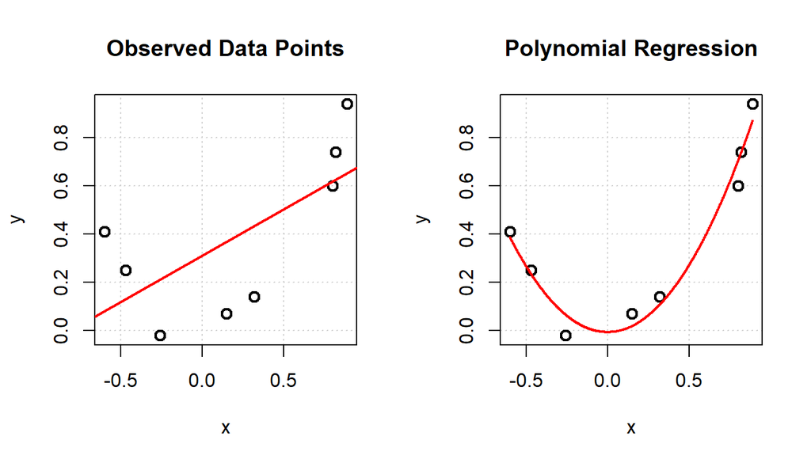

```r
x <- c(-0.47, -0.26, 0.15, 0.82, -0.6, 0.80, 0.89, 0.32)
y <- c(0.25, -0.02, 0.07, 0.74, 0.41, 0.60, 0.94, 0.14)

plot(x, y, type = 'p')
abline(lm(y ~ x), col='red')

plot(x, y, type = 'p')
model <- lm(y ~ x + I(x ^ 2))
xticks <- seq(from = min(x), to = max(x), length.out = 1000)
lines(xticks, predict(model, newdata = data.frame(x = xticks)), col='red')
```

```r
summary(model)
```

```
Call:
lm(formula = y ~ x + I(x^2))

Residuals:
        1         2         3         4         5         6         7         8
 0.015154 -0.087275  0.050159  0.001398  0.022780 -0.102841  0.069301  0.031323

Coefficients:
             Estimate Std. Error t value Pr(>|t|)
(Intercept) -0.005722   0.045619  -0.125 0.905069
x            0.005357   0.063302   0.085 0.935845
I(x^2)       1.100433   0.125286   8.783 0.000317 ***
---
Signif. codes:  0 '***' 0.001 '**' 0.01 '*' 0.05 '.' 0.1 ' ' 1

Residual standard error: 0.07382 on 5 degrees of freedom
Multiple R-squared:  0.9669,    Adjusted R-squared:  0.9536
F-statistic: 72.94 on 2 and 5 DF,  p-value: 0.0001999
```

- In R, we can use either `I(x ^ p)` or `poly(x, p, raw = TRUE)` syntax to construct polynomial variables. Note `x ^ p` without `I()` does not work because it is for variable interaction later. For `poly()` function, we need `raw = TRUE` because otherwise it would construct the “orthogonal” version which is a complicated topic in [experimental design](https://en.wikipedia.org/wiki/Design_of_experiments).

```r
poly(x, 2, raw = TRUE)
```

```
         1      2
[1,] -0.47 0.2209
[2,] -0.26 0.0676
[3,]  0.15 0.0225
[4,]  0.82 0.6724
[5,] -0.60 0.3600
[6,]  0.80 0.6400
[7,]  0.89 0.7921
[8,]  0.32 0.1024
attr(,"degree")
[1] 1 2
attr(,"class")
[1] "poly"   "matrix"
```

```r
summary(lm(y ~ poly(x, 2, raw = TRUE))) # Same as lm(y ~ x + I(x ^ 2))
```

```
Call:
lm(formula = y ~ poly(x, 2, raw = TRUE))

Residuals:
        1         2         3         4         5         6         7         8
 0.015154 -0.087275  0.050159  0.001398  0.022780 -0.102841  0.069301  0.031323

Coefficients:
                         Estimate Std. Error t value Pr(>|t|)
(Intercept)             -0.005722   0.045619  -0.125 0.905069
poly(x, 2, raw = TRUE)1  0.005357   0.063302   0.085 0.935845
poly(x, 2, raw = TRUE)2  1.100433   0.125286   8.783 0.000317 ***
---
Signif. codes:  0 '***' 0.001 '**' 0.01 '*' 0.05 '.' 0.1 ' ' 1

Residual standard error: 0.07382 on 5 degrees of freedom
Multiple R-squared:  0.9669,    Adjusted R-squared:  0.9536
F-statistic: 72.94 on 2 and 5 DF,  p-value: 0.0001999
```

- In the example above, the observed data were simulated from a pure quadratic function $y = x^2 + \epsilon$ with noise $\epsilon\sim\mathcal{N}(0, 0.01)$. The estimated intercept $\beta_0^* \approx 0$ and linear term $\beta_1^*\approx 0$ are both close to 0. Nonetheless, we should still fit the full quadratic model (with intercept and linear terms)
  $$y = \beta_0 + \beta_1 x + \beta_2 x^2 +
  \epsilon$$
  instead of the pure quadratic model
  $$y = \beta_2 x^2 +\epsilon$$

```r
summary(lm(y ~ 0 + I(x ^ 2))) # Same as lm(y ~ I(x ^ 2) - 1)
```

```
Call:
lm(formula = y ~ 0 + I(x^2))

Residuals:
     Min       1Q   Median       3Q      Max
-0.10100 -0.02088  0.01187  0.03222  0.07240

Coefficients:
       Estimate Std. Error t value Pr(>|t|)
I(x^2)  1.09532    0.04826    22.7 8.17e-08 ***
---
Signif. codes:  0 '***' 0.001 '**' 0.01 '*' 0.05 '.' 0.1 ' ' 1

Residual standard error: 0.06261 on 7 degrees of freedom
Multiple R-squared:  0.9866,    Adjusted R-squared:  0.9847
F-statistic: 515.1 on 1 and 7 DF,  p-value: 8.166e-08
```

- Why? If we apply an affine transformation $x\mapsto x+1$ to transform the explanatory variable, then the relationship between $y$ and $x$ becomes
  $$y
  = \beta_2 (x + 1)^2 + \epsilon = \beta_2 + 2 \beta_2 x + \beta_2 x^2 +
  \epsilon$$
  The lower-degree terms (i.e. intercept and linear terms) re-appear. Therefore, in order to preserve the invariance property of linear regression model with respect to affine transformation, it is best practice to keep all lower-degree terms $x^0=1,\,x,\,x^2,\dotsc,\,x^{p-1}$ up to the highest degree $x^p$ of our polynomial regression. (This continues to hold when we consider higher-order interaction terms later.)